# Настройка NFS

Лабораторная работа №13

Элсаиед Адел

Российский университет дружбы народов, Москва, Россия

6 января 2026

# Цели и задачи работы

## Цель лабораторной работы

Приобретение навыков настройки сервера NFSv4 для удалённого доступа к ресурсам и организации общего дерева каталогов в сетевой среде.

# Выполнение работы

## Установка ПО на сервере

На серверной виртуальной машине установлены необходимые пакеты для работы NFS (nfs-utils) и зависимости. Подготовлена программная база для запуска сервера NFS.

[figure not shown]

## Создание корня дерева NFS

Создан каталог `/srv/nfs`, который используется в качестве корневого каталога экспортируемого дерева NFS.

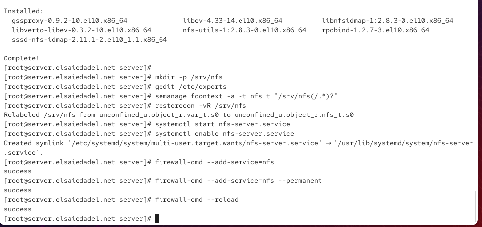

Создание /srv/nfs

## Экспорт общего ресурса

В файле `/etc/exports` задан экспорт каталога `/srv/nfs` с доступом только на чтение для всех узлов сети. Это обеспечивает доступ клиентам без возможности модификации данных.

[figure not shown]

## SELinux и запуск службы NFS

Выполнена настройка SELinux для экспортируемого каталога и применены контексты безопасности. Служба `nfs-server` запущена и добавлена в автозагрузку.

[figure not shown]

## Доступ клиента к экспортам

На клиенте выполнена проверка экспортов сервера. После корректной настройки межсетевого экрана команда отображает доступные экспортируемые каталоги, подтверждая работоспособность NFS.

[figure not shown]

## Анализ RPC-служб и настройка firewall

На сервере выполнен анализ служб, участвующих в удалённом монтировании (rpcbind, mountd, statd). Добавлены необходимые сервисы в настройки `firewalld` для корректного удалённого доступа.

[figure not shown]

## Монтирование NFS на клиенте

На клиенте выполнено монтирование удалённого ресурса в `/mnt/nfs`. В выводе монтирования подтверждено использование `nfs4` и сетевые параметры соединения.

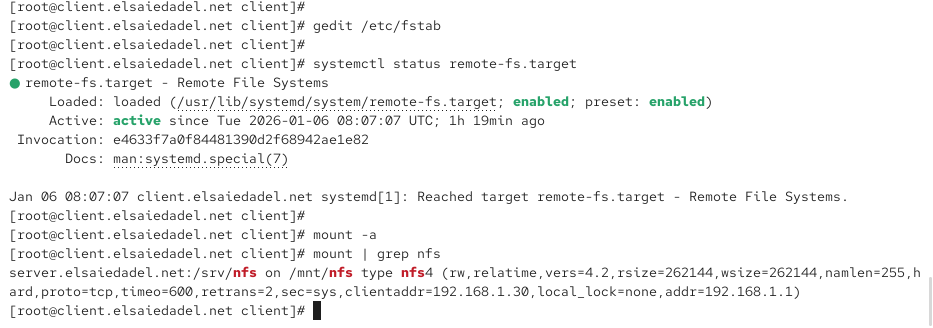

Проверка состояния монтирования

## Подключение каталога веб-сервера в дерево NFS

На сервере создан каталог `/srv/nfs/www` и выполнено bind-монтирование `/var/www` в дерево NFS. Это позволяет публиковать контент веб-сервера через NFS без копирования данных.

[figure not shown]

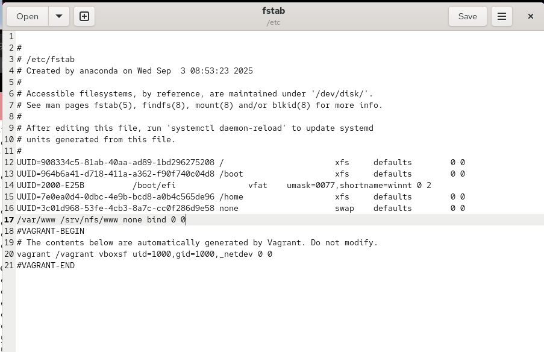

Bind-монтирование /var/www

## Проверка дерева NFS на клиенте

На клиенте проверено содержимое `/mnt/nfs`: каталог `www` отображается корректно, структура дерева NFS доступна.

[figure not shown]

## Экспорт каталога www с правами записи

В `/etc/exports` добавлен экспорт `/srv/nfs/www` для подсети `192.168.0.0/16` с правами чтения/записи. После применения экспорта доступ к каталогу проверен на клиенте.

[figure not shown]

## Постоянное bind-монтирование web-каталога

В `/etc/fstab` на сервере добавлена запись для постоянного bind-монтирования, чтобы конфигурация сохранялась после перезагрузки.

[figure not shown]

## Подключение пользовательского каталога common

[figure not shown]

## Привязка common в дерево NFS

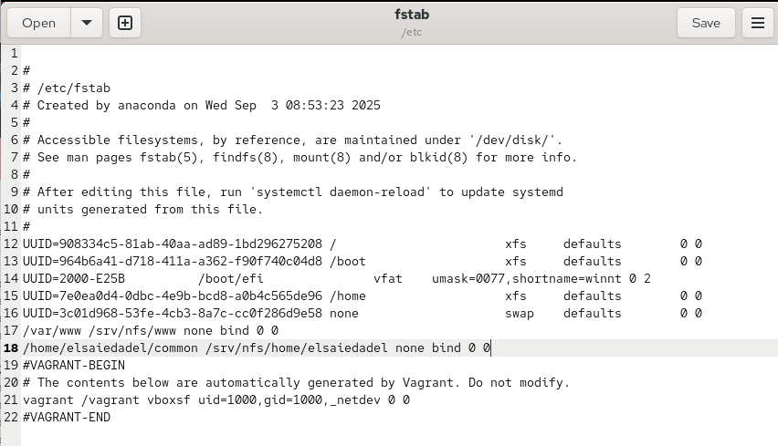

## Экспорт пользовательского каталога

[figure not shown]

## Проверка работы пользователя на клиенте

На клиенте проверено наличие каталогов `home` и `www`. В пользовательском каталоге подтверждена возможность создания файла под пользователем. При попытке доступа под root фиксируется ограничение доступа, что соответствует модели прав и политике безопасности.

[figure not shown]

# Выводы

## Вывод

В ходе работы выполнена настройка NFSv4 в виртуальной среде: настроены экспорты, SELinux и межсетевой экран, реализовано монтирование на клиенте и подключение дополнительных каталогов через bind-монтирование. Обеспечено разграничение доступа для пользовательского каталога и подтверждена корректная синхронизация данных между сервером и клиентом.